# Final Project

Alethea (Xuechun) Lin

```r
library(readr)
library(dplyr)
```

```r
library(ggplot2)
library(viridis)
library(stringi)
library(tidyr)
library(methods)
```

# Introduction

The dataset I will be working with comes from the World Bank website. The goal of this project is to use different clustering algorithms to find subgroups/clusters in the *World Development Indicator* dataset. Clustering is a type of unsupervised learning to divide the dataset into multiple groups where observations that are more “similar” are placed in the same cluster. Unlike the supervised learning models we have been learning in this course where we have already assigned identity/responses (i.e. they are already in groups) to each observation, clustering is simply trying to use the variables in our observations to group them into separate responses based on the “similarity” of these observations.

In my dataset, the different countries are the observations, and the development indicators (access to electricity, population, mortality rate etc.) are the variables.

Unsupervised learning is very important for data scientists because it allows you to find patterns in data that made no sense beforehand. There are a lot of clustering algorithms out there. In this project, I will use the kmeans clustering method and hierarchical clustering method.

# Data Cleansing

```r
world <- read_csv("~/Desktop/Data_Extract_From_World_Development_Indicators/WDI.csv")
head(world)
```

```
## # A tibble: 6 x 9
##   `Country Name` `Country Code`
##            <chr>          <chr>
## 1    Afghanistan            AFG
## 2    Afghanistan            AFG
## 3    Afghanistan            AFG
## 4    Afghanistan            AFG
## 5    Afghanistan            AFG
## 6    Afghanistan            AFG
## # ... with 7 more variables: `Series Name` <chr>, `Series Code` <chr>,
## #   `2013 [YR2013]` <chr>, `2014 [YR2014]` <chr>, `2015 [YR2015]` <chr>,
## #   `2016 [YR2016]` <chr>, `2017 [YR2017]` <chr>
```

The initial data from the World Bank was arranged in an undesirable way, so I needed to clean it up.

```r
names(world) <- c("country", "country_code", "series", "series_code", "YR2013", "YR2014","YR2015","YR2016","YR2017")
world$YR2013 <- as.numeric(world$YR2013)
world$YR2014 <- as.numeric(world$YR2014)
world$YR2015 <- as.numeric(world$YR2015)
world$YR2016 <- as.numeric(world$YR2016)
world$YR2017 <- as.numeric(world$YR2017)
```

The original data contained development indicators from 2013-2017, but there were a lot of missing entries as well as duplicates, so I first created a small set for each year to decided which year’s data I want to work with:

1. select, delete duplicates, and restructure the data
2. only keep columns (indicators) with less than 28 missing values
3. only keep rows (countries) with no missing values

## 2013

```r
world_2013 <- select(world, series, YR2013, country)
world_2013 <- world_2013[!duplicated(world_2013),]
world_2013 <- spread(world_2013, series, YR2013)
```

```r
num_missing <- apply(is.na(world_2013), 2, sum)
world_2013 <- world_2013[,num_missing < 28]
```

```r
num_missing <- apply(is.na(world_2013), 1, sum)
world_2013 <- world_2013[num_missing == 0,]
```

## 2014

```r
world_2014 <- select(world, series, YR2014, country)
world_2014 <- world_2014[!duplicated(world_2014),]
world_2014 <- spread(world_2014, series, YR2014)
```

```r
num_missing <- apply(is.na(world_2014), 2, sum)
world_2014 <- world_2014[,num_missing < 28]
```

```r
num_missing <- apply(is.na(world_2014), 1, sum)
world_2014 <- world_2014[num_missing == 0,]
```

## 2015

```r
world_2015 <- select(world, series, YR2015, country)
world_2015 <- world_2015[!duplicated(world_2015),]
world_2015 <- spread(world_2015, series, YR2015)
```

```r
num_missing <- apply(is.na(world_2015), 2, sum)
world_2015 <- world_2015[,num_missing < 28]
```

```r
num_missing <- apply(is.na(world_2015), 1, sum)
world_2015 <- world_2015[num_missing == 0,]
```

## 2016

```r
world_2016 <- select(world, series, YR2016, country)
world_2016 <- world_2016[!duplicated(world_2016),]
world_2016 <- spread(world_2016, series, YR2016)
```

```r
num_missing <- apply(is.na(world_2016), 2, sum)
world_2016 <- world_2016[,num_missing < 28]
```

```r
num_missing <- apply(is.na(world_2016), 1, sum)
world_2016 <- world_2016[num_missing == 0,]
```

## 2017

```r
world_2017 <- select(world, series, YR2017, country)
world_2017 <- world_2017[!duplicated(world_2017),]
world_2017 <- spread(world_2017, series, YR2017)
```

```r
num_missing <- apply(is.na(world_2017), 2, sum)
world_2017 <- world_2017[,num_missing < 28]
```

```r
num_missing <- apply(is.na(world_2017), 1, sum)
world_2017 <- world_2017[num_missing == 0,]
```

```r
dim(world_2013)
```

```
## [1] 125 174
```

```r
dim(world_2014)
```

```
## [1] 137 168
```

```r
dim(world_2015)
```

```
## [1] 138 136
```

```r
dim(world_2016)
```

```
## [1] 158  94
```

```r
dim(world_2017)
```

```
## [1] 193   6
```

2013 and 2014 had the most data to work with. I wanted to keep as many countries as possible, so I am going with year 2014 for the rest of my project.

Let’s also look at what indicators we will be working with.

```r
names(world_2014)
```

```
##   [1] "country"
##   [2] "Access to electricity (% of population)"
##   [3] "Access to electricity, rural (% of rural population)"
##   [4] "Access to electricity, urban (% of urban population)"
##   [5] "Adjusted savings: education expenditure (% of GNI)"
##   [6] "Adjusted savings: mineral depletion (current US$)"
##   [7] "Adolescent fertility rate (births per 1,000 women ages 15-19)"
##   [8] "Age dependency ratio (% of working-age population)"
##   [9] "Age dependency ratio, old (% of working-age population)"
##  [10] "Age dependency ratio, young (% of working-age population)"
##  [11] "Agricultural land (% of land area)"
##  [12] "Agricultural land (sq. km)"
##  [13] "Arable land (% of land area)"
##  [14] "Arable land (hectares per person)"
##  [15] "Arable land (hectares)"
```

[output cut: 153 more lines]

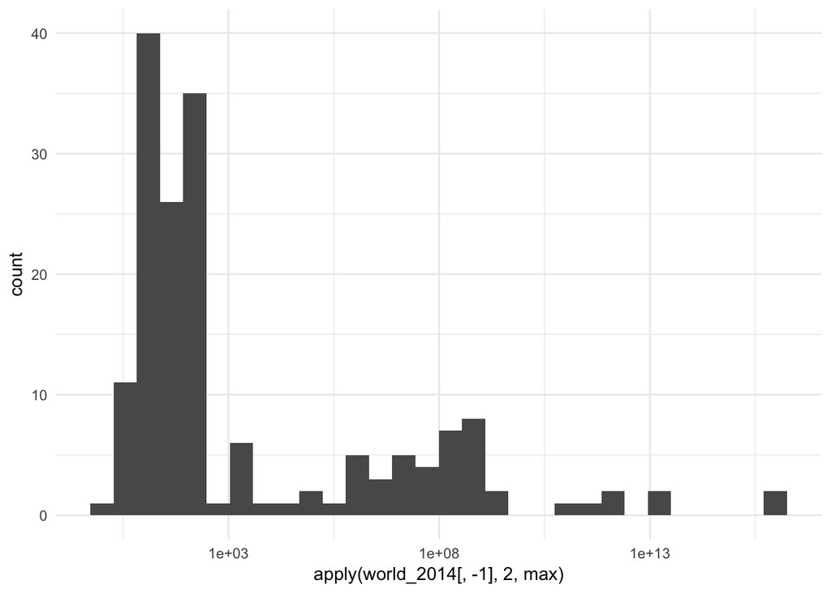

```r
qplot(apply(world_2014[,-1], 2, max)) +
  scale_x_log10() +
  theme_minimal()
```

The chart above illustrates the number of variables whose max is in each buckets on a scale from zero to the trillions. On the left, it’s probably the variables like percentages, rates. In the middle, it’s the variables like arable land, population, and mobile cellular subscriptions that are on the millions scale, and also variables like foreign direct investments and merchandise exports that are on the billions scale. On the right, it’s the variables like GDP which is on the trillions scale.

As we can see, the different indicators have different scales. The value for GDP is much larger than that for percentages (there are a lot of indicators in the form of percentages).

While some clustering algorithms can be used for categorical variables, kmeans and hierarchical clustering are mostly used for numerical variables. Both algorithms use distances between observations to measure dissimilarity, so if our variables are on different scales, the variable on a larger scale will tend to have bigger differences, and thus will be the driver for the dissimilarity between observations. In this case, I would like to let all the variables have equal weight because they are not comparable with each other, so I will scale my variables.

```r
world_2014_copy <- world_2014
world_2014_copy$country <-NULL
world_2014_matrix <- data.matrix(world_2014_copy)
world_2014_matrix <- scale(world_2014_matrix)
```

# Clustering

Now we have a clean matrix to apply our clustering algorithms!

## K-means Algorithm

K-means is the most basic and most commonly used clustering algorithm. It works as following:

1. pick random centroids to start with.
2. assign each observation to the different centroids by computing the euclidean distances between the centroid and all of the observations, the goal is to assign each observation to the closest centroid.
3. for the resulting clusters, compute the centroid within each cluster so that the sum of the distances between all the oberservations to the centroid is minimized.
4. repeat 2 and 3 until the assignments no longer change.

Here’s a visual way of understanding the algorithm from http://sherrytowers.com/2013/10/24/k-means-clustering/

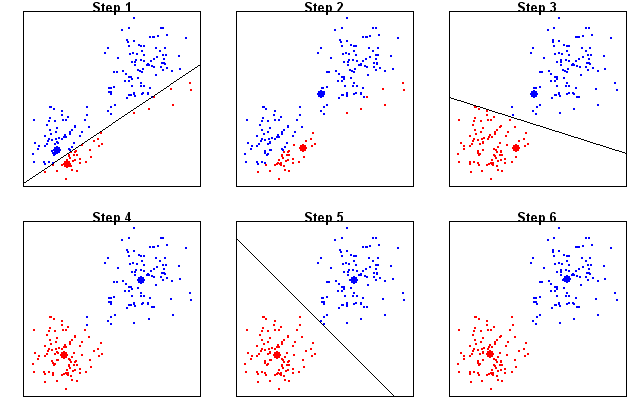

To use the kmeans algorithm, the first step is to determine the optimal number of centroids. There are multiple methods that can help determine the optimal number of centroids.

1.`pamk` function:

```r
library(fpc)
clusters <- pamk(world_2014_matrix)
n <- clusters$nc
n
```

```
## [1] 2
```

2.“elbow” method:

The idea here is that the within-cluster variance will continue to decrease as the number of cluster increases. However, the extent of such decrease in variance will begin to be not so significant at some number of cluster, and this point will be the optimal number of clusters because increasing the number of clusters will not effectively decrease the within-cluster variance anymore.

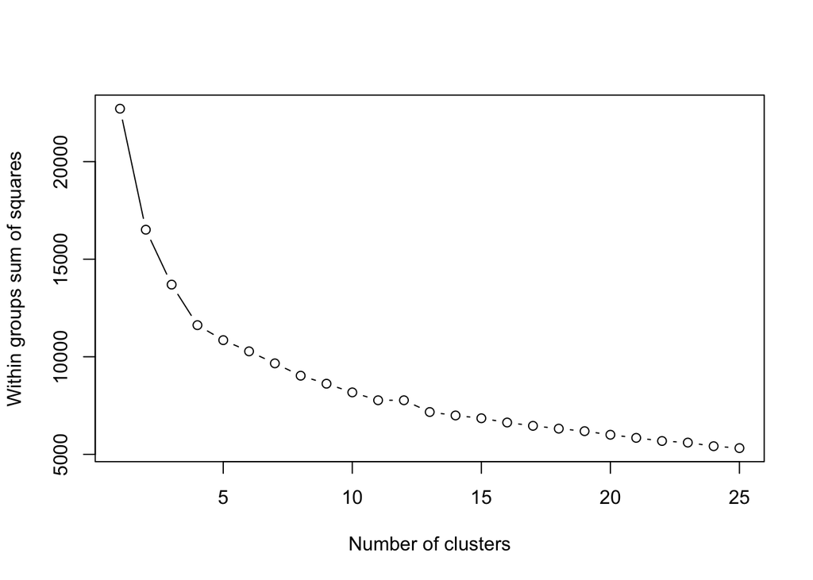

```r
wss<- (nrow(world_2014_matrix)-1)*sum(apply(world_2014_matrix,2,var))

for (i in 2:25) wss[i] <- sum(kmeans(world_2014_matrix,
centers=i, nstart = 20)$withinss)
plot(1:25, wss, type="b", xlab="Number of clusters",
ylab="Within groups sum of squares")
```

```r
dev.copy(png,filename="elbowMethod.png", width=600, height=875);
```

```r
dev.off ();
```

The preceding code is taken from Tal Galili’s post based on Chapter 16, R in Action, Second Edition, By Rob Kabacoff.

So these two methods drew different conclusions about how many clusters are optimal. `famk` method stated 2 clusters, while “elbow” method stated 4 clusters. I will then look at the results using 2 and 4 clusters.

### 2 Clusters

```r
results <- kmeans(world_2014_matrix, 2, nstart=20)
table(results$cluster)
```

```
##
##  1  2
## 58 79
```

```r
ta_data <- data_frame(country = world_2014$country,
                      cluster = results$cluster)
ta_data <- left_join(ta_data, unique(select(world, country, country_code)))
geo <- read_csv("https://gist.githubusercontent.com/tadast/8827699/raw/7255fdfbf292c592b75cf5f7a19c16ea59735f74/countries_codes_and_coordinates.csv")
geo <- geo[,c(3,5,6)]
names(geo) <- c("country_code", "latitude", "longitude")
geo$country_code <- stri_replace_all(geo$country_code, "", fixed = "\"")
geo$latitude <- as.numeric(stri_replace_all(geo$latitude, "", fixed = "\""))
geo$longitude <- as.numeric(stri_replace_all(geo$longitude, "", fixed = "\""))
ta_data <- left_join(ta_data, geo)
```

```
## Using zoom = 2...
```

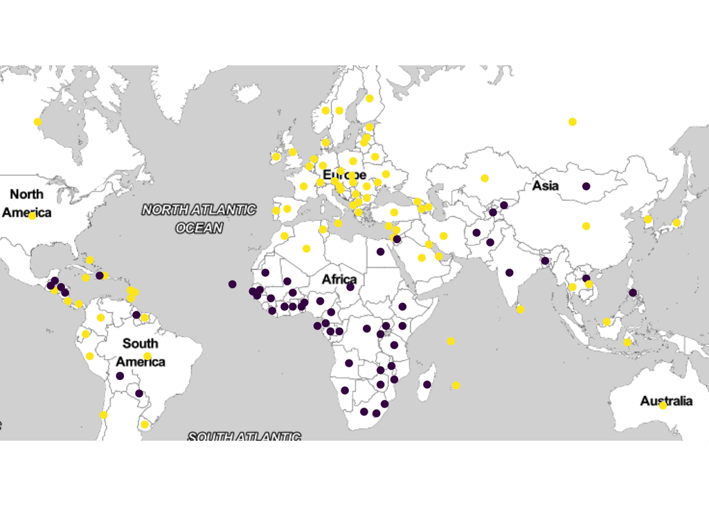

```r
library(ggmap)
qmplot(longitude, latitude, data = filter(ta_data, longitude > -100, longitude < 140),
       color = factor(cluster), show.legend = FALSE, size = I(2)) +
  viridis::scale_color_viridis(discrete = TRUE)
```

As you may suspect, it seems like the dataset has been split into more developed countries and less developed countries. Let’s compare our clustering results to what Wikimedia Commons says.

Source: https://commons.wikimedia.org/wiki/File:Developed_and_developing_countries.PNG

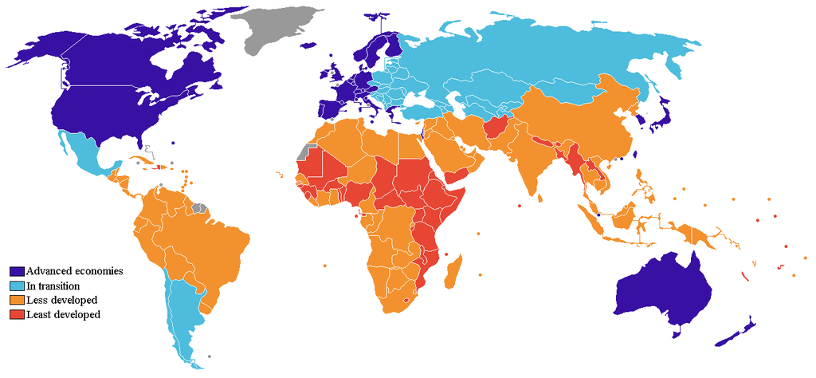

I will then look at the average value of the variables in the two clusters. It seems to make sense. One cluster contains more developed countries with higher percent of access to electricity, lower adolescent fertility rate, lower birth rate and fertility rate, higher CO2 emission, longer years of compulsory education, more fixed broadband and telephone subscriptions, more foreigh direct investment, higher GDP and GDP per capita, higher percent of access to improved sanitation facilities, lower incidence of tuberculosis, longer life expectancy at birth, lower mortality rate, and so on…

```r
aggregate(world_2014_copy,by=list(results$cluster),FUN=mean)
```

```
##   Group.1 Access to electricity (% of population)
## 1       1                                57.52417
## 2       2                                99.31563
##   Access to electricity, rural (% of rural population)
## 1                                             41.38375
## 2                                             97.95635
##   Access to electricity, urban (% of urban population)
## 1                                             77.89838
## 2                                             99.77775
##   Adjusted savings: education expenditure (% of GNI)
## 1                                           3.861610
## 2                                           4.595281
##   Adjusted savings: mineral depletion (current US$)
## 1                                         639023658
## 2                                        2851636324
##   Adolescent fertility rate (births per 1,000 women ages 15-19)
## 1                                                      83.81530
## 2                                                      26.20071
##   Age dependency ratio (% of working-age population)
## 1                                           75.44242
## 2                                           47.75747
##   Age dependency ratio, old (% of working-age population)
## 1                                                6.273026
## 2                                               18.409014
##   Age dependency ratio, young (% of working-age population)
## 1                                                  69.16940
## 2                                                  29.34845
##   Agricultural land (% of land area) Agricultural land (sq. km)
## 1                           44.76314                   220612.1
## 2                           39.44275                   382610.2
##   Arable land (% of land area) Arable land (hectares per person)
## 1                     14.79228                         0.1938564
## 2                     17.85257                         0.2675405
##   Arable land (hectares) Birth rate, crude (per 1,000 people)
## 1                6855898                             31.70741
## 2               11185001                             13.64270
##   Capture fisheries production (metric tons) CO2 emissions (kt)
## 1                                   280171.6           63895.45
## 2                                   839339.7          358505.69
##   CO2 emissions (metric tons per capita)
```

[output cut: 341 more lines]

```
##   Terrestrial protected areas (% of total land area)
## 1                                           15.55328
## 2                                           18.42684
##   Total fisheries production (metric tons)
## 1                                 474662.5
## 2                                1942215.0
##   Total natural resources rents (% of GDP)
## 1                                11.040032
## 2                                 4.886149
##   Tuberculosis case detection rate (%, all forms) Urban population
## 1                                        62.34483         17556353
## 2                                        82.12658         32300605
##   Urban population (% of total) Urban population growth (annual %)
## 1                      43.04633                           3.418439
## 2                      68.62214                           1.134779
```

Here is the list of countries in each cluster:

```r
as.list(world_2014[results$cluster==1,1])
```

```
## $country
##  [1] "Afghanistan"           "Angola"
##  [3] "Bangladesh"            "Belize"
##  [5] "Benin"                 "Bolivia"
##  [7] "Burkina Faso"          "Cabo Verde"
##  [9] "Cameroon"              "Chad"
## [11] "Congo, Dem. Rep."      "Congo, Rep."
## [13] "Cote d'Ivoire"         "Egypt, Arab Rep."
## [15] "Equatorial Guinea"     "Ethiopia"
## [17] "Gabon"                 "Gambia, The"
## [19] "Ghana"                 "Guatemala"
## [21] "Guinea"                "Guinea-Bissau"
## [23] "Guyana"                "Haiti"
## [25] "Honduras"              "India"
## [27] "Jordan"                "Kenya"
## [29] "Kiribati"              "Kyrgyz Republic"
## [31] "Lao PDR"               "Lesotho"
## [33] "Liberia"               "Madagascar"
## [35] "Malawi"                "Mali"
## [37] "Mauritania"            "Mongolia"
## [39] "Mozambique"            "Namibia"
## [41] "Nicaragua"             "Nigeria"
## [43] "Pakistan"              "Paraguay"
## [45] "Philippines"           "Rwanda"
## [47] "Samoa"                 "Sao Tome and Principe"
## [49] "Senegal"               "South Africa"
## [51] "Swaziland"             "Tajikistan"
## [53] "Tanzania"              "Togo"
## [55] "Tonga"                 "Uganda"
## [57] "Zambia"                "Zimbabwe"
```

```r
as.list(world_2014[results$cluster==2,1])
```

```
## $country
##  [1] "Albania"             "Algeria"             "Armenia"
##  [4] "Australia"           "Austria"             "Azerbaijan"
##  [7] "Bahamas, The"        "Barbados"            "Belarus"
## [10] "Belgium"             "Brazil"              "Bulgaria"
## [13] "Canada"              "Chile"               "China"
## [16] "Colombia"            "Costa Rica"          "Croatia"
## [19] "Cyprus"              "Czech Republic"      "Denmark"
## [22] "Dominican Republic"  "Ecuador"             "El Salvador"
## [25] "Estonia"             "Finland"             "France"
## [28] "Georgia"             "Germany"             "Greece"
## [31] "Hungary"             "Indonesia"           "Iran, Islamic Rep."
## [34] "Ireland"             "Israel"              "Jamaica"
## [37] "Japan"               "Kazakhstan"          "Korea, Rep."
## [40] "Kuwait"              "Latvia"              "Lebanon"
## [43] "Lithuania"           "Macedonia, FYR"      "Malaysia"
## [46] "Malta"               "Mauritius"           "Mexico"
## [49] "Moldova"             "Morocco"             "Netherlands"
## [52] "Norway"              "Panama"              "Peru"
## [55] "Poland"              "Portugal"            "Qatar"
## [58] "Romania"             "Russian Federation"  "Saudi Arabia"
## [61] "Serbia"              "Seychelles"          "Slovak Republic"
## [64] "Slovenia"            "Spain"               "Sri Lanka"
## [67] "St. Lucia"           "Suriname"            "Sweden"
## [70] "Switzerland"         "Thailand"            "Trinidad and Tobago"
## [73] "Tunisia"             "Turkey"              "Ukraine"
## [76] "United Kingdom"      "United States"       "Uruguay"
## [79] "Vietnam"
```

So now we have divided our observations (countries) into 2 subgroups, we can use these subgroups as the response, and fit a supervised model to it. I will use the glmnet model to find which variables correlate to which cluster. The code below will help me understand what variables had the most weight in determining the assignment of clusters.

```r
X <- world_2014_matrix
y <- results$cluster

library(glmnet)
model <- cv.glmnet(X, y, alpha = 0.9, family = "multinomial")

beta <- coef(model, s = model$lambda.1se)
beta <- Reduce(cbind, beta)

beta[apply(beta != 0, 1, any),]
```

```
## 23 x 2 sparse Matrix of class "dgCMatrix"
##                                                                  1
## (Intercept)                                            -0.35877368
## Crop production index (2004-2006 = 100)                 0.08687570
## GDP (constant LCU)                                     -0.06339316
## Incidence of tuberculosis (per 100,000 people)          0.16730115
## Individuals using the Internet (% of population)       -0.10493629
## Life expectancy at birth, female (years)               -0.06552571
## Life expectancy at birth, total (years)                -0.08950632
## Mobile cellular subscriptions (per 100 people)         -0.01278632
## Number of neonatal deaths                               0.01131581
## Population ages 0-14 (% of total)                       0.08953012
## Population ages 0-14, female (% of total)               0.21058756
## Population ages 0-4, female (% of female population)    0.15582561
## Population ages 10-14, female (% of female population)  0.14377823
## Population ages 15-19, female (% of female population)  0.19667154
## Population ages 40-44, female (% of female population) -0.41548367
## Population ages 5-9, female (% of female population)    0.01704232
## Population ages 50-54, male (% of male population)     -0.29285942
## Population ages 55-59, male (% of male population)     -0.17214161
## Population ages 60-64, male (% of male population)     -0.06250462
## Rural population (% of total population)                0.13413138
## Rural population growth (annual %)                      0.02818467
## Survival to age 65, male (% of cohort)                 -0.05732713
## Urban population (% of total)                          -0.12258467
##                                                                  1
## (Intercept)                                             0.35877368
## Crop production index (2004-2006 = 100)                -0.08687570
## GDP (constant LCU)                                      0.06339316
## Incidence of tuberculosis (per 100,000 people)         -0.16730115
## Individuals using the Internet (% of population)        0.10493629
## Life expectancy at birth, female (years)                0.06552571
## Life expectancy at birth, total (years)                 0.08950632
## Mobile cellular subscriptions (per 100 people)          0.01278632
## Number of neonatal deaths                              -0.01131581
## Population ages 0-14 (% of total)                      -0.08953012
## Population ages 0-14, female (% of total)              -0.21058756
## Population ages 0-4, female (% of female population)   -0.15582561
## Population ages 10-14, female (% of female population) -0.14377823
## Population ages 15-19, female (% of female population) -0.19667154
## Population ages 40-44, female (% of female population)  0.41548367
## Population ages 5-9, female (% of female population)   -0.01704232
## Population ages 50-54, male (% of male population)      0.29285942
## Population ages 55-59, male (% of male population)      0.17214161
## Population ages 60-64, male (% of male population)      0.06250462
## Rural population (% of total population)               -0.13413138
## Rural population growth (annual %)                     -0.02818467
## Survival to age 65, male (% of cohort)                  0.05732713
## Urban population (% of total)                           0.12258467
```

We can see that cluster 1 (less developed countries) is positively correlated to crop production index, incidence of tuberculosis, number of neonatal deaths, younger populations (age 0-19), and percent of rural population, while cluster 2 (more developed countries) is positively correlated to GDP, percent of indiciduals using the internet, life expectancy at birth, mobile cellular subscriptions, older populations (age 50-64), percent of survival to age 65, and percent of urban population. Kind of cool to see this!

### 4 Clusters

Now let’s do the same thing to divide the dataset into 4 clusters.

```r
set.seed(1)
results <- kmeans(world_2014_matrix, 4, nstart=20)
table(results$cluster)
```

```
##
##  1  2  3  4
## 43 38  3 53
```

```r
ta_data <- data_frame(country = world_2014$country,
                      cluster = results$cluster)
ta_data <- left_join(ta_data, unique(select(world, country, country_code)))
geo <- read_csv("https://gist.githubusercontent.com/tadast/8827699/raw/7255fdfbf292c592b75cf5f7a19c16ea59735f74/countries_codes_and_coordinates.csv")
geo <- geo[,c(3,5,6)]
names(geo) <- c("country_code", "latitude", "longitude")
geo$country_code <- stri_replace_all(geo$country_code, "", fixed = "\"")
geo$latitude <- as.numeric(stri_replace_all(geo$latitude, "", fixed = "\""))
geo$longitude <- as.numeric(stri_replace_all(geo$longitude, "", fixed = "\""))
ta_data <- left_join(ta_data, geo)
```

```
## Using zoom = 2...
```

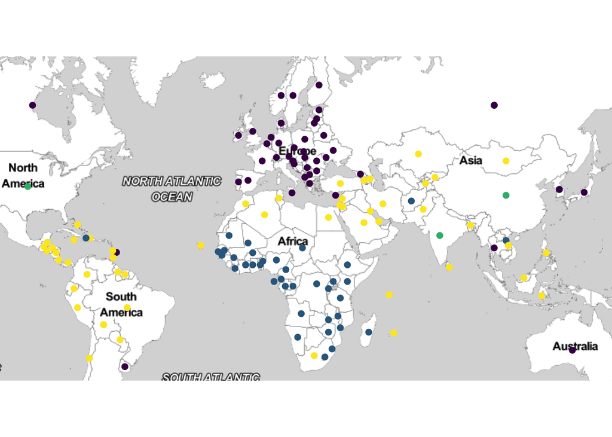

```r
library(ggmap)
qmplot(longitude, latitude, data = filter(ta_data, longitude > -100, longitude < 140),
       color = factor(cluster), show.legend = FALSE, size = I(2)) +
  viridis::scale_color_viridis(discrete = TRUE)
```

As we can see, most of the countries in Africa are in one cluster, and most of the countries in Europe are in another cluster, and countries in South America, Carribeans, Mid-East, Southeast Asia are in another cluster. The last cluster consists of China, India, and North America, which makes me think that population probably has a large weight.

```r
aggregate(world_2014_copy,by=list(results$cluster),FUN=mean)
```

```
##   Group.1 Access to electricity (% of population)
## 1       1                                99.99203
## 2       2                                40.24429
## 3       3                                93.05642
## 4       4                                95.74013
##   Access to electricity, rural (% of rural population)
## 1                                             99.94072
## 2                                             20.10785
## 3                                             90.00966
## 4                                             90.70247
##   Access to electricity, urban (% of urban population)
## 1                                             99.99484
## 2                                             67.30597
## 3                                             99.42312
## 4                                             98.95989
```

[output cut: 645 more lines]

```r
as.list(world_2014[results$cluster==1,1])
```

```
## $country
##  [1] "Albania"            "Australia"          "Austria"
##  [4] "Barbados"           "Belarus"            "Belgium"
##  [7] "Bulgaria"           "Canada"             "Croatia"
## [10] "Cyprus"             "Czech Republic"     "Denmark"
## [13] "Estonia"            "Finland"            "France"
## [16] "Georgia"            "Germany"            "Greece"
## [19] "Hungary"            "Ireland"            "Japan"
## [22] "Korea, Rep."        "Latvia"             "Lithuania"
## [25] "Macedonia, FYR"     "Malta"              "Moldova"
## [28] "Netherlands"        "Norway"             "Poland"
## [31] "Portugal"           "Romania"            "Russian Federation"
## [34] "Serbia"             "Slovak Republic"    "Slovenia"
## [37] "Spain"              "Sweden"             "Switzerland"
## [40] "Thailand"           "Ukraine"            "United Kingdom"
## [43] "Uruguay"
```

```r
as.list(world_2014[results$cluster==2,1])
```

```
## $country
##  [1] "Afghanistan"           "Angola"
##  [3] "Benin"                 "Burkina Faso"
##  [5] "Cameroon"              "Chad"
##  [7] "Congo, Dem. Rep."      "Congo, Rep."
##  [9] "Cote d'Ivoire"         "Equatorial Guinea"
## [11] "Ethiopia"              "Gabon"
## [13] "Gambia, The"           "Ghana"
## [15] "Guinea"                "Guinea-Bissau"
## [17] "Haiti"                 "Kenya"
## [19] "Kiribati"              "Lao PDR"
## [21] "Lesotho"               "Liberia"
## [23] "Madagascar"            "Malawi"
## [25] "Mali"                  "Mauritania"
## [27] "Mozambique"            "Namibia"
## [29] "Nigeria"               "Rwanda"
## [31] "Sao Tome and Principe" "Senegal"
## [33] "Swaziland"             "Tanzania"
## [35] "Togo"                  "Uganda"
## [37] "Zambia"                "Zimbabwe"
```

```r
as.list(world_2014[results$cluster==3,1])
```

```
## $country
## [1] "China"         "India"         "United States"
```

```r
as.list(world_2014[results$cluster==4,1])
```

```
## $country
##  [1] "Algeria"             "Armenia"             "Azerbaijan"
##  [4] "Bahamas, The"        "Bangladesh"          "Belize"
##  [7] "Bolivia"             "Brazil"              "Cabo Verde"
## [10] "Chile"               "Colombia"            "Costa Rica"
## [13] "Dominican Republic"  "Ecuador"             "Egypt, Arab Rep."
## [16] "El Salvador"         "Guatemala"           "Guyana"
## [19] "Honduras"            "Indonesia"           "Iran, Islamic Rep."
## [22] "Israel"              "Jamaica"             "Jordan"
## [25] "Kazakhstan"          "Kuwait"              "Kyrgyz Republic"
## [28] "Lebanon"             "Malaysia"            "Mauritius"
## [31] "Mexico"              "Mongolia"            "Morocco"
## [34] "Nicaragua"           "Pakistan"            "Panama"
## [37] "Paraguay"            "Peru"                "Philippines"
## [40] "Qatar"               "Samoa"               "Saudi Arabia"
## [43] "Seychelles"          "South Africa"        "Sri Lanka"
## [46] "St. Lucia"           "Suriname"            "Tajikistan"
## [49] "Tonga"               "Trinidad and Tobago" "Tunisia"
## [52] "Turkey"              "Vietnam"
```

Here, I will apply the glmnet model again to the clusters. However, one problem is that glmnet does not like when a subgroup contains less than 8 observations. The clustering results separated China, U.S., and India as one cluster, which makes a lot of sense, and I don’t think we should reduce the cluster number to 3. So in the glmnet model below, I will only use the other 3 cluters to see the correlation between cluster assignment and variables.

```r
set.seed(1)
X <- world_2014_matrix
y <- results$cluster

tab <- table(y)
index <- which(y %in% names(tab)[tab > 8])

library(glmnet)
model <- cv.glmnet(X[index,], y[index], alpha = 0.9, family = "multinomial")

beta <- coef(model, s = model$lambda.1se)
beta <- Reduce(cbind, beta)

beta[apply(beta != 0, 1, any),]
```

```
## 30 x 3 sparse Matrix of class "dgCMatrix"
##                                                                              1
## (Intercept)                                                        -0.40512197
## Access to electricity (% of population)                             .
## Access to electricity, rural (% of rural population)                .
## Age dependency ratio (% of working-age population)                  .
## Arable land (% of land area)                                        0.10495537
## Arable land (hectares per person)                                   0.08316301
## Compulsory education, duration (years)                              .
## Death rate, crude (per 1,000 people)                                .
## Fixed broadband subscriptions (per 100 people)                      0.23657592
## Improved sanitation facilities (% of population with access)        .
## Livestock production index (2004-2006 = 100)                        .
## Mortality rate, neonatal (per 1,000 live births)                    .
## Mortality rate, under-5 (per 1,000 live births)                     .
## People practicing open defecation (% of population)                 .
## People using basic drinking water services (% of population)        .
## People using basic sanitation services (% of population)            .
## Population ages 15-64, female (% of total)                          .
## Population ages 20-24, female (% of female population)             -0.58802365
## Population ages 25-29, female (% of female population)              .
## Population ages 55-59, female (% of female population)              0.04891754
## Population ages 60-64, female (% of female population)              0.22735646
## Population ages 60-64, male (% of male population)                  0.15385543
## Population ages 65 and above (% of total)                           0.01976056
## Population ages 65 and above, male (% of total)                     0.02892222
## Population ages 70-74, female (% of female population)              0.78746399
## Population ages 70-74, male (% of male population)                  0.90005831
## Population ages 75-79, male (% of male population)                  0.40613586
## Preprimary education, duration (years)                              .
## Renewable energy consumption (% of total final energy consumption)  .
## Secure Internet servers (per 1 million people)                      0.13981629
##                                                                               1
## (Intercept)                                                        -0.493917925
## Access to electricity (% of population)                            -0.038896514
## Access to electricity, rural (% of rural population)               -0.811808136
## Age dependency ratio (% of working-age population)                  0.188486156
## Arable land (% of land area)                                        .
## Arable land (hectares per person)                                   .
## Compulsory education, duration (years)                              .
```

[output cut: 39 more lines]

```
## People using basic sanitation services (% of population)            .
## Population ages 15-64, female (% of total)                          .
## Population ages 20-24, female (% of female population)              .
## Population ages 25-29, female (% of female population)              0.1200685
## Population ages 55-59, female (% of female population)              .
## Population ages 60-64, female (% of female population)              .
## Population ages 60-64, male (% of male population)                  .
## Population ages 65 and above (% of total)                           .
## Population ages 65 and above, male (% of total)                     .
## Population ages 70-74, female (% of female population)              .
## Population ages 70-74, male (% of male population)                  .
## Population ages 75-79, male (% of male population)                  .
## Preprimary education, duration (years)                             -0.1627954
## Renewable energy consumption (% of total final energy consumption) -0.2500529
## Secure Internet servers (per 1 million people)                      .
```

Overall, K-means algorithm seems to provide us with a lot of interesting information!

# Connectivity-based (Hierarchical) clustering

Remember that using the k-means algorithm requires an input of the number of clusters, but this can be difficult if you have no idea how many clusters you should have. Hierarchical clustering, on the other hand, does not require an initial input on the number of clusters. Instead, it maps out the entire process of forming clusters, or dividing up clusters. Hierarchical clustering can be divided into two approaches:

*Agglomerative vs. Divisive*

*Agglomerative*: the process of fusing the n observations into groups, eventually end up with 1 final group containing all n observations.

*Divisive*: the process of breaking down the n observations into groups, eventually end up with n final groups each containing 1 observation.

Both approaches will allow us to see what the optimal division of groups. In the end, we can observe the entire fusing/dividing process through a *dendrogram*, which illustrates the entire clustering process.

Just like k-means, the similarity between observations is measured through the distances. However, while k-means uses euclidean distances only, hierarchical learning allows the choices of different methods for distance calculation.For binary data, there are *Jaccard coefficient*, *Rogers and Tanimoto*, *Sneath and Sokal*, and *Gower and Legendre*. For multivariable continuous data, there are *Euclidean*, *Manhattan*, *Minkowski*, *Pearson correlation*, and *Angular separation*. For this project, I will use the most commonly used *Euclidean* distance.

This article has a great table for the comparison of different distance http://journals.plos.org/plosone/article/file?id=10.1371/journal.pone.0144059&type=printable

What is hierarchical clustering?

The agglomerative approach is similar but opposite from the divisive approach. Agglomerative hierarchical clustering is the most commonly adapted algorithm, so I will describe the process as following:

1. Start with each observation as their own group
2. measure the distances between each observation, and notice that there can be different ways of calculating the distances. Then, you can choose different methods to follow in order to decide which two observations to fuse together. The methods are:
- single linkage: this will result in the fusion of the closest two observations/groups
- complete linkage: this will result in the fusion of the furthest two observations/groups
- average linkage: this will fuse the observations/groups with the smallest average distance between all pairs of observations from each group
- centroid linkage: this will fuse the groups with the smallest distance between the centroids of each group
- Ward’s method: this will fuse based on the increase in sum of squares for all variables within clusters after fusion
3. The fusion will continue to take place until all of the observations have been fused into one group, which contains all of the observations.

The process above will be recorded and demonstrated through the *dendrogram*, where the fusions at each stage are shown, and the height of each fusion represents the distance upon such fusion.

Below, I will illustrate how the dendrograms differ for each of the linkage methods. All of the distances are measured as euclidean distances.

### Complete Linkage

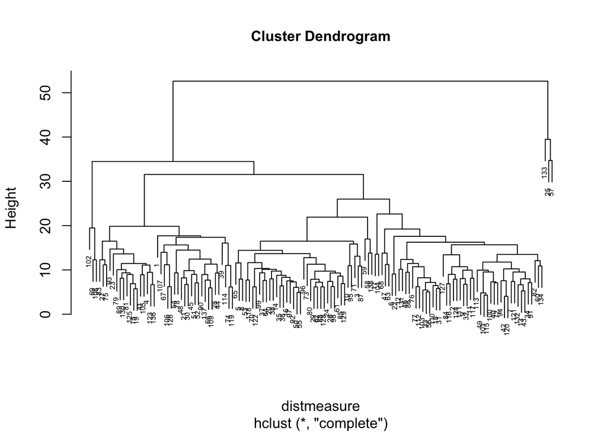

```r
set.seed(1)
distmeasure<- dist(world_2014_matrix, method = "euclidean")
cluster<- hclust(distmeasure, method="complete")
plot(cluster, cex=0.5, cex.lab=1, cex.axis=1, cex.main=1, cex.sub=1, which.plots=2)
```

### Single Linkage

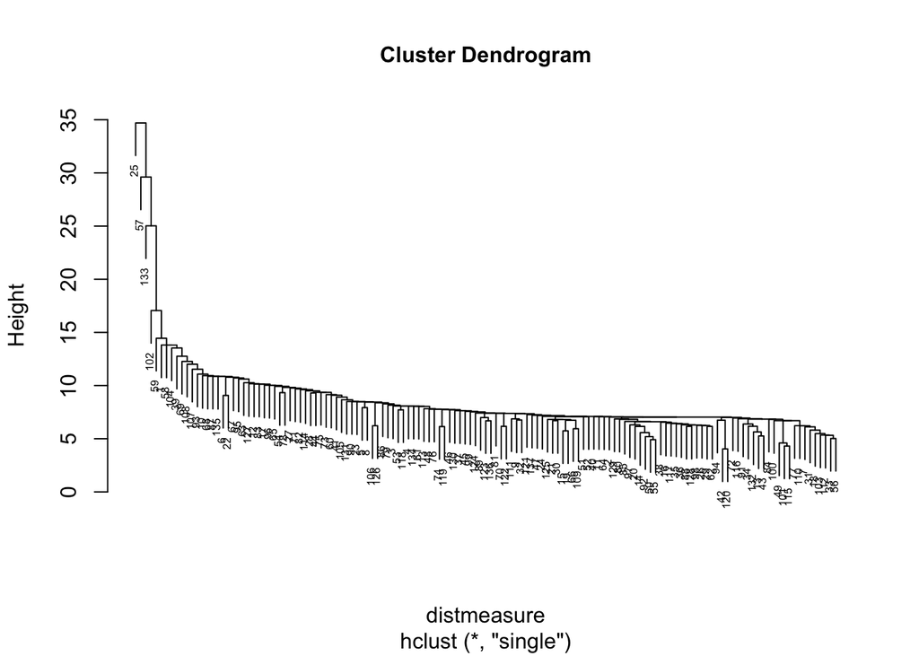

```r
set.seed(1)
distmeasure<- dist(world_2014_matrix, method = "euclidean")
cluster<- hclust(distmeasure, method="single")
plot(cluster, cex=0.5, cex.lab=1, cex.axis=1, cex.main=1, cex.sub=1, which.plots=2)
```

### Average Linkage

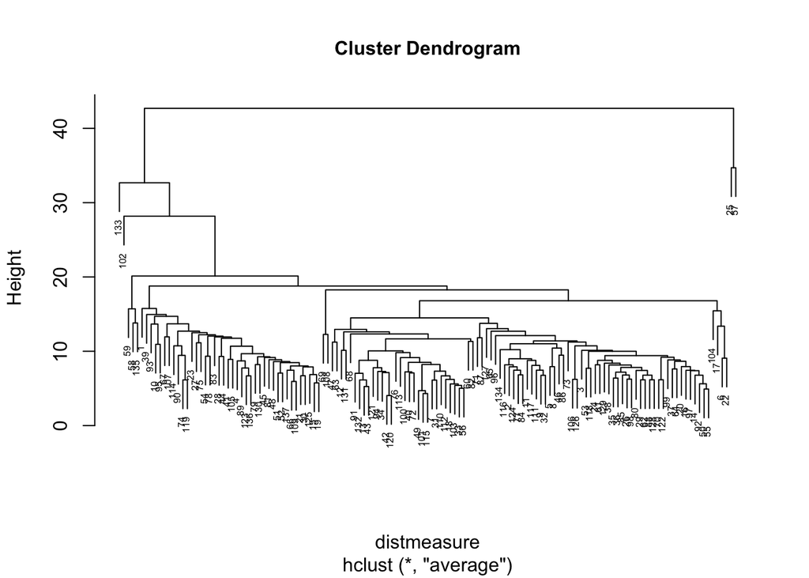

```r
set.seed(1)
distmeasure<- dist(world_2014_matrix, method = "euclidean")
cluster<- hclust(distmeasure, method="average")
plot(cluster, cex=0.5, cex.lab=1, cex.axis=1, cex.main=1, cex.sub=1, which.plots=2)
```

### Ward’s Method

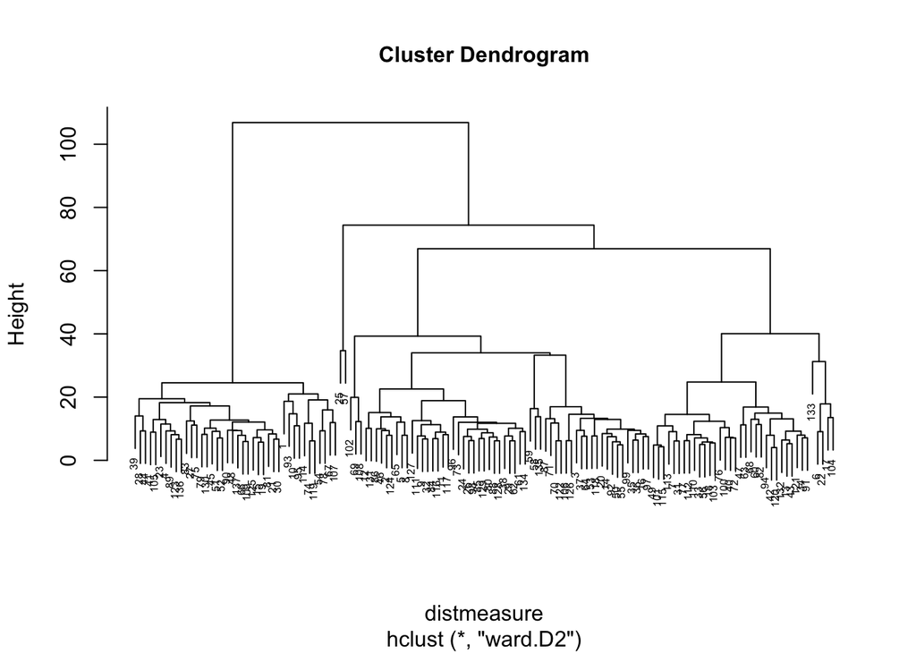

```r
set.seed(1)
distmeasure<- dist(world_2014_matrix, method = "euclidean")
cluster<- hclust(distmeasure, method="ward.D2")
plot(cluster, cex=0.5, cex.lab=1, cex.axis=1, cex.main=1, cex.sub=1, which.plots=2)
```

Now, here is the beauty of dendrograms, you can look at the dendrograms and decide what the optimal cluster number is. In this dendrogram above, 4 clusters seem reasonable, so let’s see what that means.

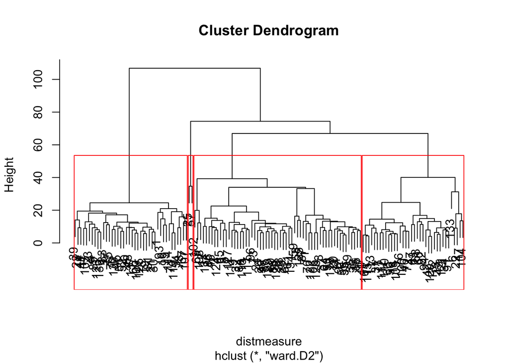

```r
set.seed(1)
plot(hclust(distmeasure, method="ward.D2"))
x <- rect.hclust(cluster, k=4, border="red")
```

```r
clusterCut <- cutree(cluster, 4)
```

```r
ta_data <- data_frame(country = world_2014$country,
                      cluster = clusterCut)
ta_data <- left_join(ta_data, unique(select(world, country, country_code)))
geo <- read_csv("https://gist.githubusercontent.com/tadast/8827699/raw/7255fdfbf292c592b75cf5f7a19c16ea59735f74/countries_codes_and_coordinates.csv")
geo <- geo[,c(3,5,6)]
names(geo) <- c("country_code", "latitude", "longitude")
geo$country_code <- stri_replace_all(geo$country_code, "", fixed = "\"")
geo$latitude <- as.numeric(stri_replace_all(geo$latitude, "", fixed = "\""))
geo$longitude <- as.numeric(stri_replace_all(geo$longitude, "", fixed = "\""))
ta_data <- left_join(ta_data, geo)
```

```
## Using zoom = 2...
```

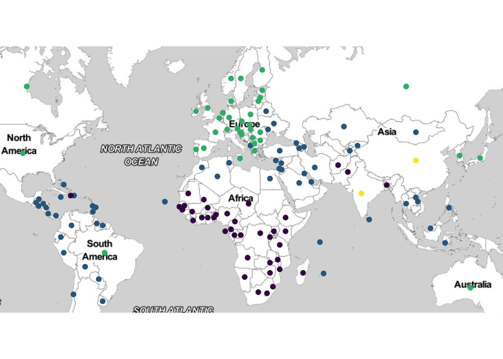

```r
ta_data <- ta_data[!duplicated(ta_data),]

library(ggmap)
qmplot(longitude, latitude, data = filter(ta_data, longitude > -100, longitude < 140),
       color = factor(cluster), show.legend = FALSE, size = I(2)) +
  viridis::scale_color_viridis(discrete = TRUE)
```

```r
as.list(world_2014[clusterCut==1,1])
```

```
## $country
##  [1] "Afghanistan"           "Angola"
##  [3] "Bangladesh"            "Benin"
##  [5] "Burkina Faso"          "Cameroon"
##  [7] "Chad"                  "Congo, Dem. Rep."
##  [9] "Congo, Rep."           "Cote d'Ivoire"
## [11] "Equatorial Guinea"     "Ethiopia"
## [13] "Gabon"                 "Gambia, The"
## [15] "Ghana"                 "Guinea"
## [17] "Guinea-Bissau"         "Haiti"
## [19] "Kenya"                 "Kiribati"
## [21] "Lesotho"               "Liberia"
## [23] "Madagascar"            "Malawi"
## [25] "Mali"                  "Mauritania"
## [27] "Mozambique"            "Namibia"
## [29] "Nigeria"               "Pakistan"
## [31] "Rwanda"                "Sao Tome and Principe"
## [33] "Senegal"               "South Africa"
## [35] "Swaziland"             "Tanzania"
## [37] "Togo"                  "Uganda"
## [39] "Zambia"                "Zimbabwe"
```

```r
as.list(world_2014[clusterCut==2,1])
```

```
## $country
##  [1] "Albania"             "Algeria"             "Armenia"
##  [4] "Azerbaijan"          "Bahamas, The"        "Barbados"
##  [7] "Belarus"             "Belize"              "Bolivia"
## [10] "Cabo Verde"          "Chile"               "Colombia"
## [13] "Costa Rica"          "Cyprus"              "Dominican Republic"
## [16] "Ecuador"             "Egypt, Arab Rep."    "El Salvador"
## [19] "Georgia"             "Guatemala"           "Guyana"
## [22] "Honduras"            "Indonesia"           "Iran, Islamic Rep."
## [25] "Israel"              "Jamaica"             "Jordan"
## [28] "Kazakhstan"          "Kuwait"              "Kyrgyz Republic"
## [31] "Lao PDR"             "Lebanon"             "Malaysia"
## [34] "Mauritius"           "Mexico"              "Moldova"
## [37] "Mongolia"            "Morocco"             "Nicaragua"
## [40] "Panama"              "Paraguay"            "Peru"
## [43] "Philippines"         "Qatar"               "Samoa"
## [46] "Saudi Arabia"        "Seychelles"          "Sri Lanka"
## [49] "St. Lucia"           "Suriname"            "Tajikistan"
## [52] "Thailand"            "Tonga"               "Trinidad and Tobago"
## [55] "Tunisia"             "Turkey"              "Ukraine"
## [58] "Uruguay"             "Vietnam"
```

```r
as.list(world_2014[clusterCut==3,1])
```

```
## $country
##  [1] "Australia"          "Austria"            "Belgium"
##  [4] "Brazil"             "Bulgaria"           "Canada"
##  [7] "Croatia"            "Czech Republic"     "Denmark"
## [10] "Estonia"            "Finland"            "France"
## [13] "Germany"            "Greece"             "Hungary"
## [16] "Ireland"            "Japan"              "Korea, Rep."
## [19] "Latvia"             "Lithuania"          "Macedonia, FYR"
## [22] "Malta"              "Netherlands"        "Norway"
## [25] "Poland"             "Portugal"           "Romania"
## [28] "Russian Federation" "Serbia"             "Slovak Republic"
## [31] "Slovenia"           "Spain"              "Sweden"
## [34] "Switzerland"        "United Kingdom"     "United States"
```

```r
as.list(world_2014[clusterCut==4,1])
```

```
## $country
## [1] "China" "India"
```

The result of hierarchical clustering seems similar to that o k-means.One obvious change is that the United States is in the cluster with mostly european countries, as opposed to staying with China and India.

Here, I will again apply the glmnet model excluding the last cluster containing China and India.

```r
X <- world_2014_matrix
y <- clusterCut

tab <- table(y)
index <- which(y %in% names(tab)[tab > 8])

model <- cv.glmnet(X[index,], y[index], alpha = 0.9, family = "multinomial")

beta <- coef(model, s = model$lambda.1se)
beta <- Reduce(cbind, beta)

beta[apply(beta != 0, 1, any),]
```

```
## 33 x 3 sparse Matrix of class "dgCMatrix"
##                                                                                    1
## (Intercept)                                                               -0.4113212
## Access to electricity (% of population)                                   -0.3182968
## Access to electricity, rural (% of rural population)                      -0.5171246
## Age dependency ratio, old (% of working-age population)                    .
## Arable land (% of land area)                                               .
## CO2 emissions from solid fuel consumption (% of total)                     .
## Death rate, crude (per 1,000 people)                                       .
## Fixed broadband subscriptions (per 100 people)                             .
## Foreign direct investment, net inflows (BoP, current US$)                  .
## Forest area (sq. km)                                                       .
## Improved sanitation facilities, urban (% of urban population with access) -0.6125279
## Incidence of tuberculosis (per 100,000 people)                             0.3150230
## Inflation, GDP deflator (annual %)                                         .
## Marine protected areas (% of territorial waters)                           .
## Mortality rate, infant (per 1,000 live births)                             0.2518723
## Mortality rate, neonatal (per 1,000 live births)                           0.1268702
## Mortality rate, under-5 (per 1,000 live births)                            0.2390565
## Number of neonatal deaths                                                  0.1970537
## People using basic sanitation services (% of population)                  -0.3086392
## Population ages 15-64, female (% of total)                                -0.2630465
## Population ages 20-24, female (% of female population)                     .
## Population ages 20-24, male (% of male population)                         .
## Population ages 65 and above (% of total)                                  .
## Population ages 65 and above, male (% of total)                            .
## Population ages 65-69, female (% of female population)                     .
## Population ages 65-69, male (% of male population)                         .
## Population ages 70-74, female (% of female population)                     .
## Population ages 70-74, male (% of male population)                         .
## Primary school starting age (years)                                        .
## Secondary education, duration (years)                                      .
## Secure Internet servers (per 1 million people)                             .
## Survival to age 65, female (% of cohort)                                  -0.1978692
## Terrestrial and marine protected areas (% of total territorial area)       .
##                                                                                       1
## (Intercept)                                                                1.0588690389
## Access to electricity (% of population)                                    .
## Access to electricity, rural (% of rural population)                       .
## Age dependency ratio, old (% of working-age population)                    .
```

[output cut: 48 more lines]

```
## People using basic sanitation services (% of population)                   .
## Population ages 15-64, female (% of total)                                 .
## Population ages 20-24, female (% of female population)                    -0.09702173
## Population ages 20-24, male (% of male population)                        -0.43769575
## Population ages 65 and above (% of total)                                  0.03865762
## Population ages 65 and above, male (% of total)                            0.14652361
## Population ages 65-69, female (% of female population)                     0.35324301
## Population ages 65-69, male (% of male population)                         0.36790681
## Population ages 70-74, female (% of female population)                     0.11740744
## Population ages 70-74, male (% of male population)                         0.40735599
## Primary school starting age (years)                                        .
## Secondary education, duration (years)                                      .
## Secure Internet servers (per 1 million people)                             0.44590508
## Survival to age 65, female (% of cohort)                                   .
## Terrestrial and marine protected areas (% of total territorial area)       0.42994015
```

For the hierarchical model, we can see that cluster 1 (african countries) is positively correlated with incidence of tuberculosis and neonatal and infant deaths. Cluster 2 (south american, carribean, mid-east, and southeast asian countries) is positively correlated with population ages 15-64, female (% of total). Cluster 3 (european countries) is positively correlated with CO2 emissions, fixed broadband subscriptions, foreign direct investments, forest area, older populations (age 65-74), secure internet servers, and terrestrial and marine protected areas.